# SIR Portugal

# 1 Concepts

- **Incubation Period**: is the time between infection and the visible appearance of symptoms.
- **Latency period**: is the period of time between infection and the ability to infect someone.

# 2 Model Hypothesis

## 2.1 Compartments

The population is assumed to be divided in three groups:

- **Susceptible** individuals
- **Infected**, symptomatic and infectious
- **Recovered**, immune from further infection

## 2.2 Discrete time

The observations, for simplicity, will be analyzed as a *discrete* time-series. In this case we will use `days`.

## 2.3 Constant Population

As a mathematical convenience, the total number of individuals is kept constant. The deaths are included in the *Recovered* group.

## 2.4 Other assumptions

- The population is considered big, so the random effects can be ignored.
- The population is considered homogeneous at any point in time. This means that the individuals of any compartment are distributed randomically.
- The disease is transmitted by proximity or contact between an infected and a susceptible individual (individual contact model - ICM).
- The susceptible individual becomes infected instantaneously, the latency period is ignored.
- The infected eventually get recovered and become immune.

```
Incongruência no dia 2010-03-24 Confirmados: 2362, ativos + obitos+ recuperados: 2366
Incongruência no dia 2010-03-16 Confirmados: 331, Soma das faixas etárias: 330
Incongruência no dia 2010-03-20 Confirmados: 1020, Soma das faixas etárias: 1019
Incongruência no dia 2010-03-27 Confirmados: 4268, Soma das faixas etárias: 4264
Incongruência no dia 2010-03-16 Confirmados: 331, Homens + Mulheres: 330
Incongruência no dia 2010-03-24 Confirmados: 2362, Homens + Mulheres: 2262
Incongruência no dia 2010-03-27 Confirmados: 4268, Homens + Mulheres: 4264
Incongruência no dia 2010-03-17 Confirmados: 448, Contato + Importados: 441
```

# 3 Extended Model

A more complex model is proposed by Churches, T[1] adding several compartments and permit a better exploration of the potential effects of various combinations and timings of interventions on COVID-19 spread.

Attention to the description of each compartment:

| Compartment | Functional definition |
| --- | --- |
| S | Susceptible individuals |
| E | Exposed **and** infected, not yet symptomatic but potentially infectious |
| I | Infected, symptomatic **and** infectious |
| Q | Infectious, but (self-)isolated |
| H | Requiring hospitalisation (would normally be hospitalised if capacity available) |
| R | Recovered, immune from further infection |
| F | Case fatality (death due to COVID-19, not other causes) |

## 3.1 Transition diagram

[interactive chart not shown]

## 3.2 Parameters

There is **a lot** of parameters. We will start with the defaults and adjust accordingly to new evidences.

[output not shown]

## 3.3 Time-variant parameters

Several of the simulation parameters can also be varied over time. That is, as well as accepting a single value, they also accept a vector of values with length equal to `nsteps`, the number of days over which the simulation runs. Assuming `nsteps=366`, we can, for example, set `quar.rate = c(rep(1/10,30), rep(1/3, 335))`. That defines a step function in which the transition-to-isolation rate for the **I** compartment is 0.1 for the first 30 days, then steps up to 0.33 thereafter, reflecting, say, a campaign or government edict to self-isolate. Of course, the vector of values can be a smooth function, or can go up then down again, or whatever you wish to model. This is an extremely powerful feature of computational models such as this, and one very hard to incorporate into purely mathematical models.

Most of the parameters for which time-variation is useful support it. If they don’t, you will receive an error message (the table above will be updated to include this information later).

# 4 Evidence

h = at least 15 days (>=15) b = median 5 d = +- 2 weeks?

https://github.com/midas-network/COVID-19/tree/master/parameter_estimates/2019_novel_coronavirus

- Incubation period: 5.1 (2.2 - 11.5)
- Symptoms to death: ~15 (11 - 17) – So, Infection to death ~20 days
- Days to double: 3-5 – Case report estimation is 20-30%
- Mortality rate: 1 - 1.3%?

# 5 Baseline simulation

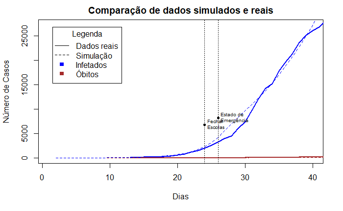

## 5.2 Baseline Prevalence

### 5.2.1 Overall

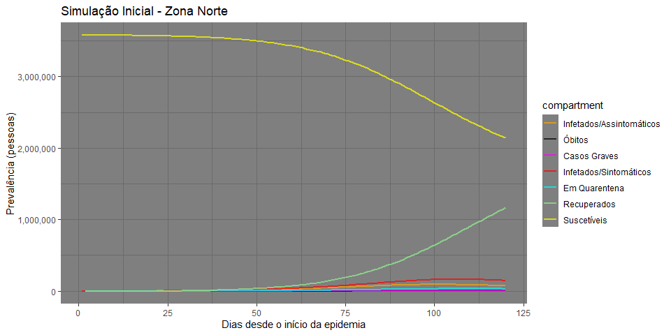

### 5.2.2 Zoom in

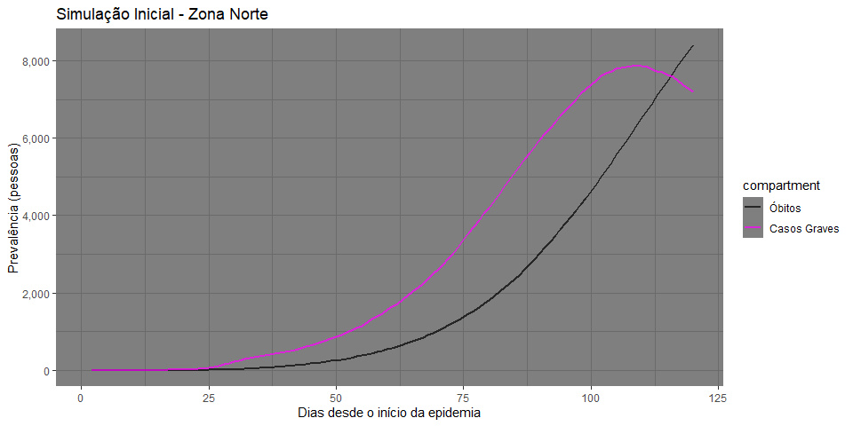

### 5.2.3 Basic reproduction number $R_{0}$

# 6 Running an intervention experiment

# 7 Other topics to review

## 7.1 Exploring public health interventions using the ICM SIR model

### 7.1.1 Avoiding exposure with social distancing

- TODO: Change the act.rate
- TODO: use different rates with sub-groups

### 7.1.2 Basic hygiene measures

- TODO: Change the inf.prob
- TODO: sub-groups?

565 -> screened for symptoms and tested for nCOV 63 -> had symptoms 8 -> had the virus 3/8 -> had symptoms

```
 beta     gamma
```

0.6671730 0.3328275

```
  R0
```

2.004561

- TODO: Estimar Re: instantaneous effective reproduction number “We’ll treat the initial 41 cases as “imported”, possibly from a different species at the Wuhan fish markets." A critical parameter for the Cori model is the serial interval (SI). The SI is the time between onset of symptoms of each case of the disease in question, and the onset of symptoms in any secondary cases that result from transmission from the primary cases. In other words, it is the time between cases in the (branching) chain of transmission of the disease.

A moment’s reflection reveals that the SI is, in fact, a statistical distribution of serial interval times, rather than a fixed value. That distribution can be simulated, typically using a discrete gamma distribution with a given mean and standard deviation.

The estimate_R() function in the EpiEstim package allows the SI distribution to be specified parametrically. It also allows uncertainty to be incorporated into the parameterisation of this distribution, and it even allows the SI distribution to be estimated empirically, using Bayesian methods, from individual line-listings of cases. We’ll examine all of those capabilities. ##

At the time of writing, I was able to find only one published estimate of the serial interval distribution, derived from analysis of just 5 primary cases amongst the first 450 cases in Wuhan, published by Li et al.. They estimate the serial interval distribution to have a mean of 7.5 days with a standard deviation of 3.4 days. This is almost identical to the serial interval parameters for the MERS virus, which were a mean of 7.6 and a SD of 3.4. This similarity is not surprising given that both pathogens are coronavirii. Let’s use that to estimate the instantaneous Re for Hubei province.

Data limitations The biggest problem with these analyses is that they are not based on data tabulated by date of onset (of symptoms), but rather on data tabulated by date of reporting, or perhaps date of confirmation by lab test. If lab testing and reporting is swift and the lag is uniform, then the date of reporting or confirmation will lag consistently and only slightly behind the date of onset. But reality is rarely so nice, and typically there are variable delays in lab confirmation and/or reporting, leading to backlogs of cases being reported all at once (known as a “data dump” by outbreak epidemiologists). This is very unfortunate, and it frustrates efforts to properly assess outbreak trajectories and effectiveness of intervention strategies. The solution is for authorities to provide line-listings of all cases, including their date of reporting and their date of onset of symptoms, even if only presumptive dates are provided (and missing dates of onset can be imputed, in any case). No details that permit identification of cases or invasion of their privacy need be provided in such line listings.

## 7.2 Data We Need

Nishiura et al. (https://www.mdpi.com/2077-0383/9/2/419) 565 -> screened for symptoms and tested for nCOV 63 -> had symptoms 8 -> had the virus 3/8 -> had symptoms

- Portugal Health-care capacity?
- Ascertainment rates?
- Time between Case0 symptoms and Case1 symptoms

# 8 References

[1] T. Churches, “Tim churches health data science blog: Modelling the effects of public health interventions on covid-19 transmission using r - part 2.” 2020, [Online]. Available: https://timchurches.github.io/blog/posts/2020-03-18-modelling-the-effects-of-public-health-interventions-on-covid-19-transmission-part-2/.